# P01CP02AD2

Antonio Lúcio

25 de outubro de 2017

[output not shown]

[output not shown]

# Análise de gastos dos deputados federais

Quem nunca teve a curiosidade de saber o quanto gasta cada deputado federal e com que ele gasta? Pois bem, cada um deles tem uma cota para gastar com suas atividades parlamentares. Ou seja, tem a disposição uma cota única mensal que é destinada a custear os seus gastos exclusivamente vinculados ao exercício da atividade parlamentar. Sabendo disto, vamos responder algumas perguntas relacionadas ao assunto.

### Quais os partidos que mais fazem uso da cota? E o quanto foi gasto no total por partido?

[interactive chart not shown]

### Quais os partidos que menos fazem uso da cota? E o quanto foi gasto no total por partido?

[interactive chart not shown]

- OBS: O partido com o nome de “séries 10” é a soma de todos os gastos declarados em que o nome do partido não está presente. Como o gasto existe, é relevante mostra-ló, ainda mais tendo em vista que é superior a outros partidos. O motivo desta ausência é uma questão a ser pesquisada.

### Das despesas realizadas pelos nossos deputados, qual a despesa mais comum? E qual foi o total gasto?

[interactive chart not shown]

### Levando em conta o estado pelo qual foi eleito o deputado, qual o estado que mais faz uso e o quanto gastou?

[interactive chart not shown]

### Levando em conta o estado pelo qual foi eleito o deputado, qual o estado que menos faz uso e o quanto gastou?

[interactive chart not shown]

- Há uma certa proporcionalidade entre gastos do estado e a quantidade de habitantes dele. Ou seja, quanto mais habitantes o estado tem, mais gastos e quantidades de usos da cota.
- Uma observação a ser feita é que o estado chamado “Series 10” são os gastos que não contém informação do estado do político que fez o gasto.

### Quais os deputados que mais gastam com sua cota parlamentar?

[interactive chart not shown]

### Quais os deputados que menos gastam com sua cota parlamentar?

[interactive chart not shown]

- OBS: É interessante investigar o motivo de existir deputados com gastos “negativos”.

### Observando pelos partidos, existe correlação entre a quantidade de gastos no exterior e o valor total gasto pelo partido(de forma geral)?

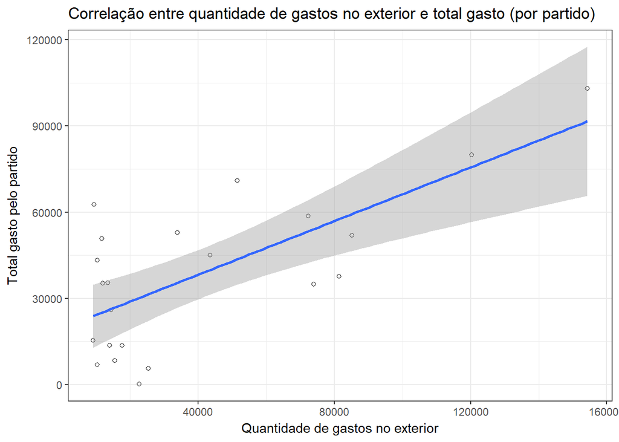

Se desconsiderarmos os partidos que menos tem quantidade de gastos no exterior, observamos uma certa correlação entre o total gasto pelo partido e gastos no exterior.

### Quais os estados cujos deputados mais gastam no exterior? E os que gastam menos?

[interactive chart not shown]